# Assignment 2

I will start by reading the data into RStudio in two separate dataframes based on dose.

```r
setwd("C:/Users/dania/Documents/Pitt/BioStats/Module 2")
x <- read.table("assignment_2_sum.txt",sep="\t",header=T)
y <- read.table("assignment_2_high.txt",sep="\t",header=T)
```

“X” is the data from patients receiving 600 mg of HCQ and “Y” is the data from patients receiving 1200 mg of HCQ. To test significant changes in PD-1 activity (defined as PD-1 MFI x cell population percentage), I will perform t tests for each cell population, comparing the low dose and high dose. To do this, I will start by entering each value under its own name.

```r
#h corresponds to helper CD4 T cells and c corresponds to cytotoxic CD8 T cells
hmem_lo <- x$CD4mem
hmem_hi <- y$CD4mem

heff_lo <- x$CD4eff
heff_hi <- y$CD4eff

hnaive_lo <- x$CD4naive
hnaive_hi <- y$CD4naive

cmem_lo <- x$CD8mem
cmem_hi <- y$CD8mem

ceff_lo <- x$CD8eff
ceff_hi <- y$CD8eff

cnaive_lo <- x$CD8naive
cnaive_hi <- y$CD8naive
```

*Question 1*: Effect of the treatment on PD-1 activity? Since we’re using MFI x cell population % to calculate PD-1 activity, there’s not much to be said about total PD-1 activity, it has to be cell type specific. I have already calculated change in PD-1 activity after treatment as % change from baseline, normalized to each patient. Now, I will run two sample t tests with Welch’s correction to determine if PD-1 activity in patients with 600mg vs 1200 mg is significantly different in specific cell subsets.

```r
t.test(hmem_hi,hmem_lo)
```

```
##
##  Welch Two Sample t-test
##
## data:  hmem_hi and hmem_lo
## t = -0.20646, df = 18.921, p-value = 0.8386
## alternative hypothesis: true difference in means is not equal to 0
## 95 percent confidence interval:
##  -38.69859  31.75116
## sample estimates:
## mean of x mean of y
##  25.45167  28.92538
```

```r
t.test(heff_hi,heff_lo)
```

```
##
##  Welch Two Sample t-test
##
## data:  heff_hi and heff_lo
## t = -0.32623, df = 22.318, p-value = 0.7473
## alternative hypothesis: true difference in means is not equal to 0
## 95 percent confidence interval:
##  -32.01679  23.30692
## sample estimates:
## mean of x mean of y
##  6.995833 11.350769
```

```r
t.test(hnaive_hi,hnaive_lo)
```

```
##
##  Welch Two Sample t-test
##
## data:  hnaive_hi and hnaive_lo
## t = 1.1198, df = 11.179, p-value = 0.2863
## alternative hypothesis: true difference in means is not equal to 0
## 95 percent confidence interval:
##  -72.41685 223.02544
## sample estimates:
## mean of x mean of y
##  43.51583 -31.78846
```

```r
t.test(cmem_hi,cmem_lo)
```

```
##
##  Welch Two Sample t-test
##
## data:  cmem_hi and cmem_lo
## t = 0.3353, df = 15.159, p-value = 0.742
## alternative hypothesis: true difference in means is not equal to 0
## 95 percent confidence interval:
##  -36.81981  50.58160
## sample estimates:
## mean of x mean of y
## 7.7616667 0.8807692
```

```r
t.test(ceff_hi,ceff_lo)
```

```
##
##  Welch Two Sample t-test
##
## data:  ceff_hi and ceff_lo
## t = 0.84724, df = 22.996, p-value = 0.4056
## alternative hypothesis: true difference in means is not equal to 0
## 95 percent confidence interval:
##  -18.60048  44.40458
## sample estimates:
##  mean of x  mean of y
##  -1.483333 -14.385385
```

```r
t.test(cnaive_hi,cnaive_lo)
```

```
##
##  Welch Two Sample t-test
##
## data:  cnaive_hi and cnaive_lo
## t = -0.84879, df = 12.127, p-value = 0.4124
## alternative hypothesis: true difference in means is not equal to 0
## 95 percent confidence interval:
##  -683.7872  300.0654
## sample estimates:
## mean of x mean of y
##  31.03833 222.89923
```

Noting is significant. I did not standardize among patients by accounting for differences in cell composition in samples. However, since we’re technically comparing each patient to themself, I don’t think this is strictly necessary.

*Question 2*: Is PD-1 activity in different cell types independent or dependent? So I think we need to run a correlation matrix for each dataset (600 mg and 1200 mg) to see if PD-1 activity changes in different cell subsets is correlated with those in another subset. However, technically Chi-squared is the test of independence, so it’s possible that Chi-squared is the only test for true independence.

```r
#I started by trying to just run cor() on x and y but it didn't work, so I made matrices of each dataset with just the % change from baseline values (no headings, no patient numbers, no dosage) so that all of the values would be numeric
setwd("C:/Users/dania/Documents/Pitt/BioStats/Module 2")
q <- read.table("assignment_2_high_matrix.txt",sep="\t",header=FALSE)
q
```

```
##        V1     V2     V3     V4     V5     V6
## 1   20.53  -2.62 -25.69 -15.64  -0.48  -8.37
## 2  -21.25 -32.84 -42.98 -32.81 -41.89 -51.07
## 3   24.27  27.65 -22.94   9.31  74.65  93.15
## 4  -16.37 -30.25  -5.80 -67.78 -43.08   4.57
## 5  -13.97  13.52 -18.93 -55.47 -45.86   7.07
## 6  -22.93 -18.06 -10.61 -19.12  19.12  14.17
## 7   22.50  12.46   2.43  62.27  -8.72 170.33
## 8   16.55   3.10 -19.05  13.68 -14.35   3.56
## 9   29.75  -8.74 -67.45   0.59  47.15  32.03
## 10  42.76  -2.27 -20.86  -7.00   6.06  43.90
## 11 152.85  22.73 -23.98 182.20 -15.33   3.85
## 12  70.73  99.27 778.05  22.91   4.93  59.27
```

```r
cor(q,method = "pearson") #1200 dose, looking at correlations between pairs of cell types
```

```
##           V1        V2         V3         V4         V5        V6
## V1 1.0000000 0.5518510 0.28199488 0.89246681 0.16795123 0.1529075
## V2 0.5518510 1.0000000 0.84054397 0.38632081 0.25012855 0.4180946
## V3 0.2819949 0.8405440 1.00000000 0.07615543 0.03179793 0.1863664
## V4 0.8924668 0.3863208 0.07615543 1.00000000 0.14968019 0.2760996
## V5 0.1679512 0.2501285 0.03179793 0.14968019 1.00000000 0.4357917
## V6 0.1529075 0.4180946 0.18636642 0.27609962 0.43579173 1.0000000
```

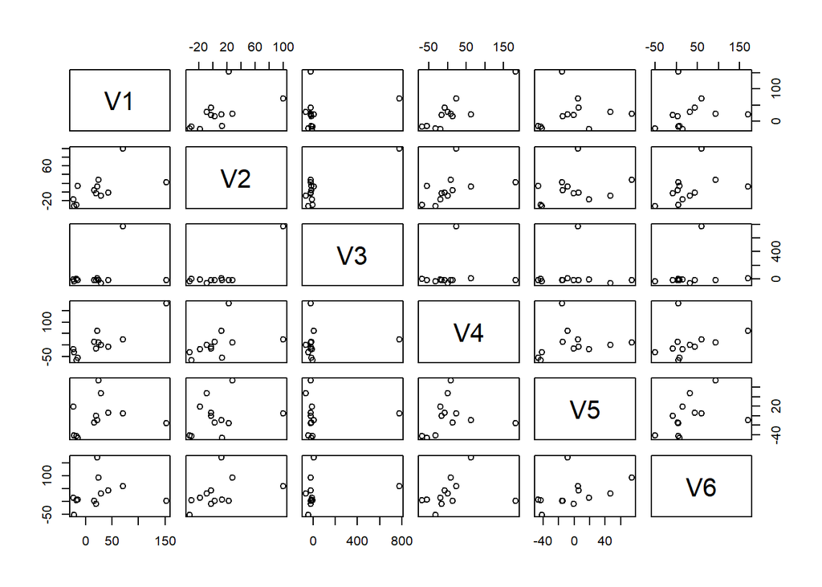

```r
plot(q)
```

```r
v <- read.table("assignment_2_sum_matrix.txt",sep="\t",header=FALSE)
v
```

```
##        V1     V2     V3     V4     V5      V6
## 1   38.10  25.40 -11.77  21.58 -20.57  -20.29
## 2   39.67 -22.74 -44.66  -0.78 -12.76  -42.46
## 3   61.94  -6.95 -21.64  35.41 -13.02   18.92
## 4   54.38  73.62 -57.63  44.72  36.47 2923.08
## 5   79.68  13.72 -28.79 -16.53  -9.81    6.79
## 6    9.41  23.98 -16.06   7.19 -59.48  -70.55
## 7   63.97  20.13 -44.42   4.40 -30.52  121.53
## 8   19.00  44.50  19.71  42.67  70.96  -20.13
## 9   15.71  17.17 -44.32 -35.28 -58.81  -34.10
## 10 -16.75  -6.98 -41.40 -31.75 -49.92  -24.44
## 11  33.35   5.21 -41.36   9.28  35.04   70.50
## 12 -34.39 -57.31 -60.54 -29.80 -46.52   -7.17
## 13  11.96  17.81 -20.37 -39.66 -28.07  -23.99
```

```r
cor(v,method = "pearson") #600 dose, looking at correlations between pairs of cell types
```

```
##            V1        V2          V3        V4        V5         V6
## V1 1.00000000 0.4477722  0.09399158 0.4932693 0.3640413  0.2615259
## V2 0.44777216 1.0000000  0.35389855 0.5355602 0.4826623  0.5898232
## V3 0.09399158 0.3538986  1.00000000 0.3734036 0.3495851 -0.3712515
## V4 0.49326934 0.5355602  0.37340365 1.0000000 0.7007689  0.4512792
## V5 0.36404127 0.4826623  0.34958512 0.7007689 1.0000000  0.3972488
## V6 0.26152592 0.5898232 -0.37125146 0.4512792 0.3972488  1.0000000
```

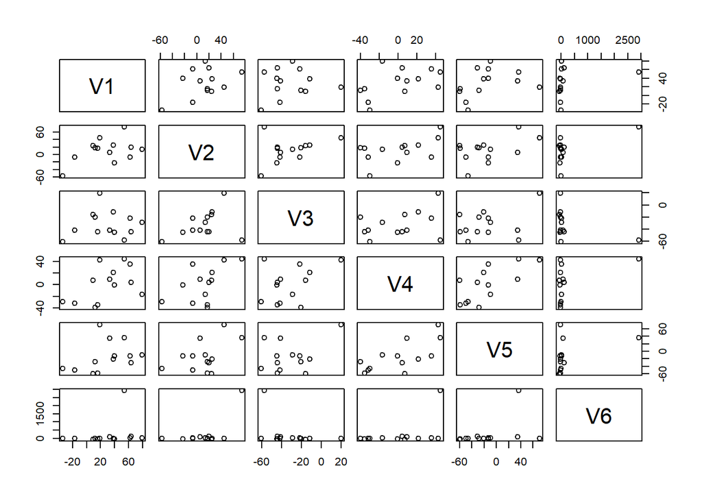

```r
plot(v)
```

```r
#now I'm wondering if I need to do a Chi-squared test, but using the chisq.test() function for q and v did not work because the values have to be "nonnegative and finite"
a <- abs(q) #taking the absolute value of q and putting it into a new variable
#now I can run the Chi-squared test
chisq.test(a)
```

```
##
##  Pearson's Chi-squared test
##
## data:  a
## X-squared = 2705.3, df = 55, p-value < 2.2e-16
```

```r
#I don't think this preserves the data accurately
```